```python
from IPython.display import HTML
HTML('''<script>
code_show=true;
function code_toggle() {
 if (code_show){
 $('div.input').hide();
 } else {
 $('div.input').show();
 }
 code_show = !code_show
}
$( document ).ready(code_toggle);
</script>
<form action="javascript:code_toggle()"><input type="submit" value="Click here to toggle on/off the raw code."></form>''')
```

# 🐍 [국토도시 빅데이터 윈터스쿨]

초급반 3조 - 김대경, 김태은, 문성일, 이복경

2019년 12월 22일

## *실제 데이터(제주도 버스 승하차 데이터)*를 기반으로 교통체증 문제 해결하기

### 국토도시 빅데이터 윈터스쿨 - 공간 빅데이터 시각화 캠프(초급)

제주도내 주민등록인구는 2019년 11월 기준 69만명으로, 연평균 4%대로 성장했습니다.  
외국인과 관광객까지 고려하면 전체 상주인구는 90만명을 넘을 것으로 추정됩니다.  
제주도민 증가와 외국인의 증가로 현재 `제주도의 교통체증이 심각한 문제`로 떠오르고 있습니다.  
2017년 한국은행 제주본부에 따르면 제주도 일부 지역은 교통체증이 서울보다 심각합니다.  
교통난 심화를 해결하기 위해 데이터 분석 대회를 개최합니다.

### 3조 프로젝트 목차

1. 서론 - 모듈 Import와 데이터 설명
2. 본론 - EDA (Exploratory Data Analysis) 및 데이터 시각화
3. 결론 - 교통체증 해결방안 제시

#### 주최사

국토연구원(KRIHS), 데이콘(DACON)

#### 후원사

과학기술정보통신부, 한국정보화진흥원

## 1. 서론: 모듈 Import와 데이터 설명

### 1.1. 데이터를 불러오고 시각화를 시키기 위해 필요한 모듈을 불러옵니다.

```python
# 시각화에 필요한 모듈을 불러옵니다.
import numpy as np
import pandas as pd
import matplotlib as mpl
import matplotlib.pyplot as plt
%matplotlib inline
import seaborn as sns
import folium
import os

# 경고 메시지를 제거합니다.
import warnings
warnings.filterwarnings('ignore')

# 한글 깨짐을 방지합니다.
from matplotlib import font_manager, rc
font_name = font_manager.FontProperties(fname="c:/Windows/Fonts/malgun.ttf").get_name()
rc('font', family=font_name)
```

```python
# 폴더 경로는 팀원 마다 상이합니다. 각자의 작업폴더로 파일을 이동합니다.
try:
    os.chdir(r"C:\Users\Kim Taeeun\Desktop\윈터스쿨_초급반\day3_해커톤\data")
    print("Current Working Directory is changed.")
except OSError:
    print("Can't change Current Working Directory.")
```

```
Current Working Directory is changed.
```

```python
# 그래프 테마를 적용합니다.
plt.style.use('ggplot')
```

### 1.2. 윈터스쿨에서 제공 받은 데이터에 대해 설명합니다. 제공된 데이터 중 train.csv 와 bus_bts.csv를 사용했습니다.

**<train.csv dataset 설명>**  
2019년 9월 제주도의 각 날짜, 출근시간(6시-12시)의 버스 정류장별 승하차 인원, 퇴근시간(18시-20시)의 버스 정류장별 승차 인원이 기록되어 있습니다.

#### ['train.csv' Table Description ]

| 변수명 | 설명 |
| --- | --- |
| id | 해당 데이터에서의 고유한 ID |
| date | 날짜 |
| bus_route_id | 버스 노선 ID |
| in_out | 시내버스, 시외버스 구분 |
| station_code | 해당 승하차 정류소의 ID |
| station_name | 해당 승하차 정류소의 이름 |
| latitude | 해당 버스 정류장의 위도 (같은 정류장 이름이어도 버스의 진행 방향에 따라 다를 수 있음) |
| longtitude | 해당 버스 정류장의 경도 (같은 정류장 이름이어도 버스의 진행 방향에 따라 다를 수 있음) |
| 6~7_ride | 6:00:00부터 6:59:59까지 승차한 인원 수 |
| 7~8_ride | 7:00:00부터 7:59:59까지 승차한 인원 수 |
| 8~9_ride | 8:00:00부터 8:59:59까지 승차한 인원 수 |
| 9~10_ride | 9:00:00부터 9:59:59까지 승차한 인원 수 |
| 10~11_ride | 10:00:00부터 10:59:59까지 승차한 인원 수 |
| 11~12_ride | 11:00:00부터 11:59:59까지 승차한 인원 수 |
| 6~7_takeoff | 6:00:00부터 6:59:59까지 하차한 인원 수 |
| 7~8_takeoff | 7:00:00부터 7:59:59까지 하차한 인원 수 |
| 8~9_takeoff | 8:00:00부터 8:59:59까지 하차한 인원 수 |
| 9~10_takeoff | 9:00:00부터 9:59:59까지 하차한 인원 수 |
| 10~11_takeoff | 10:00:00부터 10:59:59까지 하차한 인원 수 |
| 11~12_takeoff | 11:00:00부터 11:59:59까지 하차한 인원 수 |
| 18~20_ride | 18:00:00부터 19:59:59까지 승차한 인원 수 |

**<bus_bts.csv dataset 설명>**  
버스 카드 별로 승하차 정보가 기록되어 있습니다. 해당 데이터는 탑승 시간대가 오전 6시부터 12시 사이인 경우만 있습니다.

#### ['bus_bts.csv' Table Description ]

| 변수명 | 설명 |
| --- | --- |
| user_card_id | 해당 승객의 버스카드ID |
| bus_route_id | 노선ID |
| vhc_id | 차량ID |
| geton_date | 해당 승객이 탑승한 날짜 |
| geton_time | 해당 승객이 탑승한 시간 |
| geton_station_code | 승차정류소의 ID |
| geton_station_name | 승차정류소의 이름 |
| getoff_date | 해당 승객이 하차한 날짜 (하차태그 없는 경우, NaN) |
| getoff_time | 해당 승객이 하차한 시간 (하차태그 없는 경우, NaN) |
| getoff_station_code | 하차정류소의 ID (하차태그 없는 경우, NaN) |
| getoff_station_name | 하차정류소의 이름 (하차태그 없는 경우, NaN) |
| user_category | 승객 구분 (하단표 참고) |
| user_count | 해당 버스카드로 계산한 인원수 (ex. 3은 3명 버스비를 해당 카드 하나로 계산한 것) |

#### ['bus_bts.csv'의 user_category(승객 구분 유형) ]

| 승객 구분 번호 | 승객 유형 설명 |
| --- | --- |
| 01 | 일반 |
| 02 | 어린이 |
| 04 | 청소년 |
| 06 | 경로 |
| 27 | 장애 일반 |
| 28 | 장애 동반 |
| 29 | 유공 일반 |
| 30 | 유공 동반 |

### 1.3. train.csv 와 bus_bts.csv의 형태를 살펴봅니다.

train.csv는 데이터프레임의 형태를 가지고 있으며, 행은 총 415423개, 열은 총 21개가 있습니다.  
bus_bts.csv는 데이터프레임의 형태를 가지고 있으며, 행은 총 2409414개, 열은 총 13개가 있습니다.

```python
train = pd.read_csv("train.csv", encoding="utf8")
print(train.info())
print(train.shape)
train.describe()
```

```
<class 'pandas.core.frame.DataFrame'>
RangeIndex: 415423 entries, 0 to 415422
Data columns (total 21 columns):
id               415423 non-null int64
date             415423 non-null object
bus_route_id     415423 non-null int64
in_out           415423 non-null object
station_code     415423 non-null int64
station_name     415423 non-null object
latitude         415423 non-null float64
longitude        415423 non-null float64
6~7_ride         415423 non-null float64
7~8_ride         415423 non-null float64
8~9_ride         415423 non-null float64
9~10_ride        415423 non-null float64
10~11_ride       415423 non-null float64
11~12_ride       415423 non-null float64
6~7_takeoff      415423 non-null float64
7~8_takeoff      415423 non-null float64
8~9_takeoff      415423 non-null float64
9~10_takeoff     415423 non-null float64
10~11_takeoff    415423 non-null float64
11~12_takeoff    415423 non-null float64
18~20_ride       415423 non-null float64
dtypes: float64(15), int64(3), object(3)
memory usage: 66.6+ MB
None
(415423, 21)
```

|  | id | bus_route_id | station_code | latitude | longitude | 6~7_ride | 7~8_ride | 8~9_ride | 9~10_ride | 10~11_ride | 11~12_ride | 6~7_takeoff | 7~8_takeoff | 8~9_takeoff | 9~10_takeoff | 10~11_takeoff | 11~12_takeoff | 18~20_ride |
| --- | --- | --- | --- | --- | --- | --- | --- | --- | --- | --- | --- | --- | --- | --- | --- | --- | --- | --- |
| count | 415423.000000 | 4.154230e+05 | 4.154230e+05 | 415423.000000 | 415423.000000 | 415423.000000 | 415423.000000 | 415423.000000 | 415423.000000 | 415423.000000 | 415423.000000 | 415423.000000 | 415423.000000 | 415423.000000 | 415423.000000 | 415423.000000 | 415423.000000 | 415423.000000 |
| mean | 207711.000000 | 2.691935e+07 | 4.209311e+04 | 33.420375 | 126.533574 | 0.305893 | 0.829699 | 0.815350 | 0.642475 | 0.599618 | 0.579393 | 0.112870 | 0.344870 | 0.516481 | 0.430922 | 0.408001 | 0.402874 | 1.242095 |
| std | 119922.434776 | 3.924652e+06 | 4.971504e+05 | 0.107996 | 0.140986 | 1.109766 | 2.255116 | 2.317561 | 1.959844 | 1.885941 | 1.942137 | 0.597714 | 1.279179 | 1.658850 | 1.485124 | 1.412839 | 1.446080 | 4.722287 |
| min | 0.000000 | 4.270000e+06 | 1.000000e+00 | 33.208350 | 126.165040 | 0.000000 | 0.000000 | 0.000000 | 0.000000 | 0.000000 | 0.000000 | 0.000000 | 0.000000 | 0.000000 | 0.000000 | 0.000000 | 0.000000 | 0.000000 |
| 25% | 103855.500000 | 2.346000e+07 | 3.200000e+02 | 33.291080 | 126.475780 | 0.000000 | 0.000000 | 0.000000 | 0.000000 | 0.000000 | 0.000000 | 0.000000 | 0.000000 | 0.000000 | 0.000000 | 0.000000 | 0.000000 | 0.000000 |
| 50% | 207711.000000 | 2.803000e+07 | 1.130000e+03 | 33.478850 | 126.529770 | 0.000000 | 0.000000 | 0.000000 | 0.000000 | 0.000000 | 0.000000 | 0.000000 | 0.000000 | 0.000000 | 0.000000 | 0.000000 | 0.000000 | 0.000000 |
| 75% | 311566.500000 | 3.003000e+07 | 2.226000e+03 | 33.500020 | 126.575890 | 0.000000 | 1.000000 | 1.000000 | 1.000000 | 0.000000 | 0.000000 | 0.000000 | 0.000000 | 0.000000 | 0.000000 | 0.000000 | 0.000000 | 1.000000 |
| max | 415422.000000 | 3.282000e+07 | 6.115101e+06 | 33.963640 | 126.965670 | 85.000000 | 94.000000 | 136.000000 | 78.000000 | 124.000000 | 99.000000 | 45.000000 | 66.000000 | 59.000000 | 65.000000 | 52.000000 | 81.000000 | 272.000000 |

```python
bus_bts = pd.read_csv("bus_bts.csv", encoding="utf8")
print(bus_bts.info())
print(bus_bts.shape)
bus_bts.describe()
```

```
<class 'pandas.core.frame.DataFrame'>
RangeIndex: 2409414 entries, 0 to 2409413
Data columns (total 13 columns):
user_card_id           float64
bus_route_id           int64
vhc_id                 int64
geton_date             object
geton_time             object
geton_station_code     int64
geton_station_name     object
getoff_date            object
getoff_time            object
getoff_station_code    float64
getoff_station_name    object
user_category          int64
user_count             int64
dtypes: float64(2), int64(5), object(6)
memory usage: 239.0+ MB
None
(2409414, 13)
```

|  | user_card_id | bus_route_id | vhc_id | geton_station_code | getoff_station_code | user_category | user_count |
| --- | --- | --- | --- | --- | --- | --- | --- |
| count | 2.409414e+06 | 2.409414e+06 | 2.409414e+06 | 2.409414e+06 | 1.513678e+06 | 2.409414e+06 | 2.409414e+06 |
| mean | 2.920959e+15 | 2.545786e+07 | 1.497948e+08 | 1.197044e+05 | 8.406106e+04 | 4.073226e+00 | 1.012212e+00 |
| std | 2.249502e+16 | 4.017593e+06 | 1.808600e+03 | 8.422198e+05 | 7.058707e+05 | 6.523765e+00 | 1.354882e-01 |
| min | 1.355555e+07 | 4.270000e+06 | 1.497911e+08 | 0.000000e+00 | 1.000000e+00 | 1.000000e+00 | 1.000000e+00 |
| 25% | 1.014140e+15 | 2.313000e+07 | 1.497932e+08 | 2.780000e+02 | 2.860000e+02 | 1.000000e+00 | 1.000000e+00 |
| 50% | 1.019150e+15 | 2.400000e+07 | 1.497936e+08 | 6.030000e+02 | 8.510000e+02 | 1.000000e+00 | 1.000000e+00 |
| 75% | 5.188320e+15 | 2.870000e+07 | 1.497970e+08 | 2.057000e+03 | 2.374000e+03 | 6.000000e+00 | 1.000000e+00 |
| max | 1.000700e+19 | 3.282000e+07 | 1.497989e+08 | 6.115101e+06 | 6.115101e+06 | 3.000000e+01 | 1.000000e+01 |

### 1.4. 데이콘에서 제공 받은 데이터를 사용하여 직접 weekday-time.csv 데이터를 제작했습니다.

**<weekday-time.csv dataset 설명>**  
요일별 승하차 정보를 정리하고 승차인원의 합과 하차인원의 합을 추가했습니다.

#### ['weekday-time.csv' Table Description ]

| 변수명 | 설명 |
| --- | --- |
| weekday | 요일 |
| 6~7_ride | 6:00:00부터 6:59:59까지 승차한 인원 수 |
| 7~8_ride | 7:00:00부터 7:59:59까지 승차한 인원 수 |
| 8~9_ride | 8:00:00부터 8:59:59까지 승차한 인원 수 |
| 9~10_ride | 9:00:00부터 9:59:59까지 승차한 인원 수 |
| 10~11_ride | 10:00:00부터 10:59:59까지 승차한 인원 수 |
| 6~7_takeoff | 6:00:00부터 6:59:59까지 하차한 인원 수 |
| 7~8_takeoff | 7:00:00부터 7:59:59까지 하차한 인원 수 |
| 8~9_takeoff | 8:00:00부터 8:59:59까지 하차한 인원 수 |
| 9~10_takeoff | 9:00:00부터 9:59:59까지 하차한 인원 수 |
| 10~11_takeoff | 10:00:00부터 10:59:59까지 하차한 인원 수 |
| 11~12_takeoff | 11:00:00부터 11:59:59까지 하차한 인원 수 |
| 18~20_ride | 18:00:00부터 19:59:59까지 승차한 인원 수 |
| ride_sum | 전체 승차인원 수의 합 |
| takeoff_sum | 전체 하차인원 수의 합 |

## 2. 본론: EDA (Exploratory Data Analysis) 및 데이터 시각화

### 2.1. train.csv 데이터에서 승하차수가 가장 높은 상위 10개 정류장을 조사합니다.

먼저 시간대별 승차, 하차를 토대로 **승차합, 하차합, 승하차합 변수**를 만듭니다.

#### [파생 변수 설명]

| 파생 변수명 | 설명 |
| --- | --- |
| ride_sum | 승차합 |
| takeoff_sum | 하차합 |
| all_sum | 승하차합 |

```python
train['ride_sum']=train['6~7_ride']+train['7~8_ride']+train['8~9_ride']+train['9~10_ride']+train['10~11_ride']+train['11~12_ride']+train['18~20_ride']

train['takeoff_sum']=train['6~7_takeoff']+train['7~8_takeoff']+train['8~9_takeoff']+train['9~10_takeoff']+train['10~11_takeoff']+train['11~12_takeoff']

train['all_sum']=train['ride_sum']+train['takeoff_sum']

train.head()
```

|  | id | date | bus_route_id | in_out | station_code | station_name | latitude | longitude | 6~7_ride | 7~8_ride | ... | 6~7_takeoff | 7~8_takeoff | 8~9_takeoff | 9~10_takeoff | 10~11_takeoff | 11~12_takeoff | 18~20_ride | ride_sum | takeoff_sum | all_sum |
| --- | --- | --- | --- | --- | --- | --- | --- | --- | --- | --- | --- | --- | --- | --- | --- | --- | --- | --- | --- | --- | --- |
| 0 | 0 | 2019-09-01 | 4270000 | 시외 | 344 | 제주썬호텔 | 33.48990 | 126.49373 | 0.0 | 1.0 | ... | 0.0 | 0.0 | 0.0 | 0.0 | 0.0 | 0.0 | 0.0 | 16.0 | 0.0 | 16.0 |
| 1 | 1 | 2019-09-01 | 4270000 | 시외 | 357 | 한라병원 | 33.48944 | 126.48508 | 1.0 | 4.0 | ... | 0.0 | 0.0 | 0.0 | 0.0 | 0.0 | 0.0 | 5.0 | 27.0 | 0.0 | 27.0 |
| 2 | 2 | 2019-09-01 | 4270000 | 시외 | 432 | 정존마을 | 33.48181 | 126.47352 | 1.0 | 1.0 | ... | 0.0 | 0.0 | 0.0 | 0.0 | 0.0 | 0.0 | 2.0 | 6.0 | 0.0 | 6.0 |
| 3 | 3 | 2019-09-01 | 4270000 | 시내 | 1579 | 제주국제공항(600번) | 33.50577 | 126.49252 | 0.0 | 17.0 | ... | 0.0 | 0.0 | 0.0 | 0.0 | 0.0 | 0.0 | 53.0 | 132.0 | 0.0 | 132.0 |
| 4 | 4 | 2019-09-01 | 4270000 | 시내 | 1646 | 중문관광단지입구 | 33.25579 | 126.41260 | 0.0 | 0.0 | ... | 0.0 | 0.0 | 0.0 | 1.0 | 0.0 | 0.0 | 0.0 | 0.0 | 1.0 | 1.0 |

5 rows × 24 columns

**station_name(정류장 이름)**을 기준으로 **행 개수**를 조사합니다. 행의 개수는 정류장의 승하차 합을 의미하지 않습니다.

```python
train.station_name.value_counts()
```

```
한라병원          3125
제주도청신제주로터리    2713
노형오거리         2507
천수동           2267
제주버스터미널       2255
              ...
산앗도              1
먼나먼루             1
크라운골프연습장         1
행원교차로            1
강화교              1
Name: station_name, Length: 1961, dtype: int64
```

station_name(정류장 이름)을 기준으로 모든 행의 승차합, 하차합, 승하차합을 산정합니다.  
기준이 정류장 이름이기 때문에 이름이 같은 정류장 간의 구분이 되지 않습니다.

```python
temp_viz = train.groupby('station_name').sum()[['ride_sum', 'takeoff_sum','all_sum']]
temp_viz
```

| station_name | ride_sum | takeoff_sum | all_sum |
| --- | --- | --- | --- |
| (구)구판장 | 61.0 | 15.0 | 76.0 |
| (구)중문동주민센터 | 1324.0 | 569.0 | 1893.0 |
| (구)중앙파출소 | 1620.0 | 1592.0 | 3212.0 |
| (구)화산초등학교 | 30.0 | 7.0 | 37.0 |
| 1100고지휴게소 | 45.0 | 55.0 | 100.0 |
| ... | ... | ... | ... |
| 흙통 | 216.0 | 151.0 | 367.0 |
| 흥국사 | 10.0 | 26.0 | 36.0 |
| 흥덕사 | 15.0 | 11.0 | 26.0 |
| 희진주유소 | 301.0 | 70.0 | 371.0 |
| 히귀반석 | 111.0 | 22.0 | 133.0 |

1961 rows × 3 columns

정류장별 승하차합을 내림차순으로 정렬하고, **station_name(정류장 이름)**을 기준으로 **상위 10개 정류장**을 추출합니다.

```python
temp_up = temp_viz.sort_index(by='all_sum', ascending=False)
temp_up = temp_up.reset_index() #station_name 컬럼이 인덱스로 지정되어 있어 인덱스를 새로 생성합니다.
temp_up_10 = temp_up.iloc[0:10]
temp_up_10
```

|  | station_name | ride_sum | takeoff_sum | all_sum |
| --- | --- | --- | --- | --- |
| 0 | 한라병원 | 46715.0 | 23743.0 | 70458.0 |
| 1 | 제주버스터미널 | 29736.0 | 20316.0 | 50052.0 |
| 2 | 제주시청(광양방면) | 32702.0 | 12986.0 | 45688.0 |
| 3 | 제주대학교 | 33629.0 | 11709.0 | 45338.0 |
| 4 | 제주시청(아라방면) | 29537.0 | 15533.0 | 45070.0 |
| 5 | 제주도청신제주로터리 | 29557.0 | 14005.0 | 43562.0 |
| 6 | 동문로터리(동문시장) | 23176.0 | 10725.0 | 33901.0 |
| 7 | 노형오거리 | 24445.0 | 8320.0 | 32765.0 |
| 8 | 제주시외버스터미널 | 29560.0 | 450.0 | 30010.0 |
| 9 | 제주국제공항(구제주방면) | 17450.0 | 10979.0 | 28429.0 |

승하차합이 가장 많은 상위 10개 정류장에 대한 그래프를 그립니다.  
본 수치는 방향이 다르지만 이름이 같은 정류장을 통합한 수치입니다.

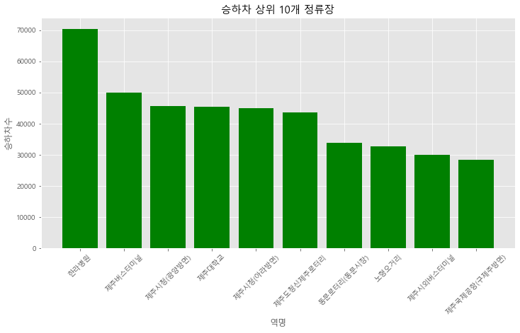

```python
fig = plt.figure(figsize=(12,6))
plt.xlabel('역명')
plt.ylabel('승하차수')
plt.title('승하차 상위 10개 정류장')
plt.bar(data=temp_up_10,x='station_name',height='all_sum',color='green')
plt.style.use('ggplot')  #격자 표시
plt.xticks(rotation=45)
plt.show()
```

**latitue(위도), longtitue(경도)**를 기준으로 승하차합이 높은 **상위 10개의 정류장**을 산정합니다.  
기준이 위경도이기 때문에 이름이 같은 정류장을 구분합니다.

```python
addr = train.groupby(['station_name','latitude', 'longitude']).sum()[['all_sum']]
addr_up = addr.sort_index(by='all_sum', ascending=False)
addr_up = addr_up.reset_index()
addr_up
addr_up_10 = addr_up.iloc[0:10]
addr_up_10
```

|  | station_name | latitude | longitude | all_sum |
| --- | --- | --- | --- | --- |
| 0 | 제주시청(광양방면) | 33.49892 | 126.53035 | 45688.0 |
| 1 | 제주시청(아라방면) | 33.49956 | 126.52977 | 45070.0 |
| 2 | 한라병원 | 33.48944 | 126.48508 | 36768.0 |
| 3 | 한라병원 | 33.48963 | 126.48600 | 33690.0 |
| 4 | 제주시외버스터미널 | 33.49946 | 126.51479 | 29789.0 |
| 5 | 제주대학교 | 33.46011 | 126.56166 | 28479.0 |
| 6 | 제주국제공항(구제주방면) | 33.50661 | 126.49345 | 28429.0 |
| 7 | 제주버스터미널 | 33.49993 | 126.51486 | 27762.0 |
| 8 | 제주국제공항(종점) | 33.50571 | 126.49319 | 27148.0 |
| 9 | 제주국제공항(신제주방면) | 33.50610 | 126.49275 | 25178.0 |

위도와 경도를 기준으로 구분한 상위 10개 정류장은 다음과 같습니다.  
정류장 간에 이름은 같지만 운행방향과 위치가 다른 곳이 존재합니다.

```python
map_osm = folium.Map(location=[33.3919083,126.5304598], zoom_start = 11) #초기 지도객체를 생성합니다.

for item in addr_up_10.index:
    lat = addr_up_10.loc[item, 'latitude']   #loc는 컬럼명으로 인덱싱합니다.
    long = addr_up_10.loc[item, 'longitude']
    folium.Marker([lat, long], #위도 경도
        popup = addr_up_10.loc[item,'station_name'],
        icon=folium.Icon(color='red', icon='info-sign')
    ).add_to(map_osm)
map_osm
```

[interactive chart not shown]

위와 같은 결과는 **거주인구 현황**과 높은 상관성을 보입니다.  
이용률이 높은 상위 10개 정류장은 인구밀집이 높은 지역에 위치합니다.  
출처: 비즈지아이에스 (Biz-gis.com), 기준년도 2018년 말 거주인구

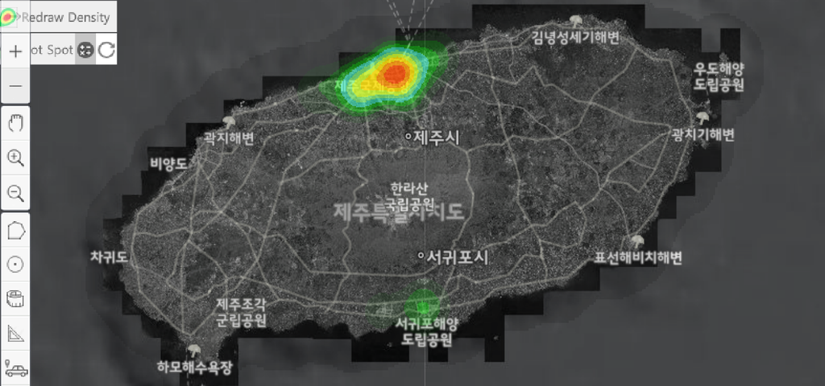

```python
from IPython.display import Image

Image(r"C:\Users\Kim Taeeun\Desktop\윈터스쿨_초급반\day3_해커톤\자료조사/인구밀집도.png")
```

### 2.2. train.csv 데이터에서 승하차가 많은 버스 노선 10개를 조사합니다.

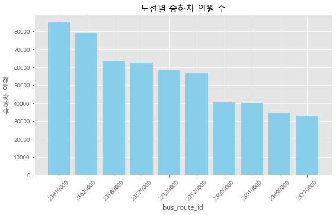

```python
data=train.loc[:,['id','date','bus_route_id','in_out','station_code','station_name','latitude','longitude',
                    'ride_sum','takeoff_sum', 'all_sum']]

data2=data.groupby(['bus_route_id','station_name'])['all_sum'].sum().to_frame().reset_index()
#data3.head()

data3=data2.groupby(['bus_route_id'])['all_sum'].sum().to_frame().reset_index()
#data4.head()

data4=data3.sort_values(by=['all_sum'],ascending=False).head(10)
data4['bus_route_id'] = data4['bus_route_id'].astype(str)

fig = plt.figure(figsize=(9,5))
plt.bar(data=data4,x='bus_route_id',height='all_sum',color='skyblue')
plt.xticks(rotation=45)
plt.xlabel('bus_route_id')
plt.ylabel('승하차 인원')
plt.title('노선별 승하차 인원 수')
plt.show()
```

train.csv에서 구분한 시간대별로 탑승 수를 확인하도록 합니다.  
**6~7시간대**의 이용객 수는 **22520000**번 노선이 가장 많습니다.

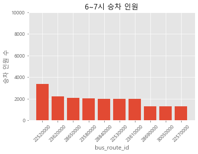

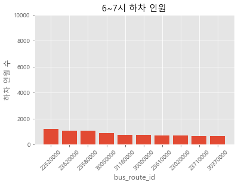

```python
data2 = train.groupby(['bus_route_id']).sum()[['6~7_ride']].reset_index()
data2=data2.sort_values(by='6~7_ride',ascending=False).head(10)
data2['bus_route_id'] = data2['bus_route_id'].astype(str)
plt.bar(x='bus_route_id',height='6~7_ride',data=data2)
plt.xticks(rotation=45)
plt.ylim([0, 10000])
plt.title('6~7시 승차 인원')
plt.xlabel('bus_route_id')
plt.ylabel('승차 인원 수')
plt.show()


data2 = train.groupby(['bus_route_id']).sum()[['6~7_takeoff']].reset_index()
data2=data2.sort_values(by='6~7_takeoff',ascending=False).head(10)
data2['bus_route_id'] = data2['bus_route_id'].astype(str)
plt.bar(x='bus_route_id',height='6~7_takeoff',data=data2)
plt.xticks(rotation=45)
plt.ylim([0, 10000])
plt.title('6~7시 하차 인원')
plt.xlabel('bus_route_id')
plt.ylabel('하차 인원 수')
plt.show()
```

**7~8시간대**의 이용객 수는 **23610000**번 노선이 가장 많습니다.

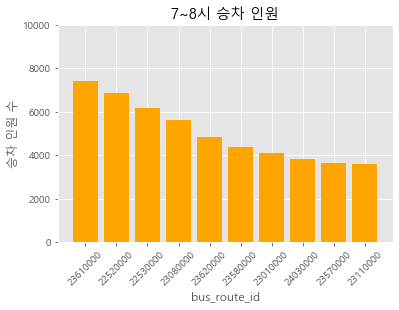

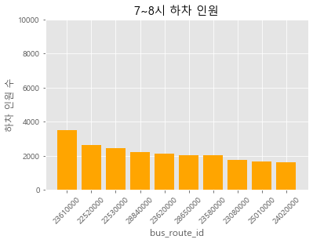

```python
data2 = train.groupby(['bus_route_id']).sum()[['7~8_ride']].reset_index()
data2=data2.sort_values(by='7~8_ride',ascending=False).head(10)
data2['bus_route_id'] = data2['bus_route_id'].astype(str)
plt.bar(x='bus_route_id',height='7~8_ride',data=data2, color='orange')
plt.xticks(rotation=45)
plt.ylim([0, 10000])
plt.title('7~8시 승차 인원')
plt.xlabel('bus_route_id')
plt.ylabel('승차 인원 수')
plt.show()

data2 = train.groupby(['bus_route_id']).sum()[['7~8_takeoff']].reset_index()
data2=data2.sort_values(by='7~8_takeoff',ascending=False).head(10)
data2['bus_route_id'] = data2['bus_route_id'].astype(str)
plt.bar(x='bus_route_id',height='7~8_takeoff',data=data2, color='orange')
plt.xticks(rotation=45)
plt.ylim([0, 10000])
plt.title('7~8시 하차 인원')
plt.xlabel('bus_route_id')
plt.ylabel('하차 인원 수')
plt.show()
```

**8~9시간대**의 이용객 수는 **23610000**번 노선이 가장 많습니다.

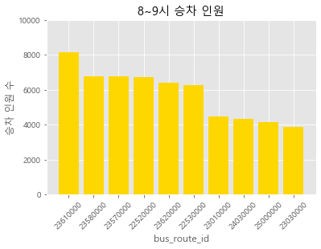

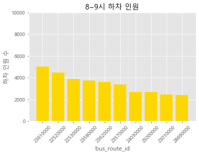

```python
data2 = train.groupby(['bus_route_id']).sum()[['8~9_ride']].reset_index()
data2=data2.sort_values(by='8~9_ride',ascending=False).head(10)
data2['bus_route_id'] = data2['bus_route_id'].astype(str)
plt.bar(x='bus_route_id',height='8~9_ride',data=data2, color='gold')
plt.xticks(rotation=45)
plt.ylim([0, 10000])
plt.title('8~9시 승차 인원')
plt.xlabel('bus_route_id')
plt.ylabel('승차 인원 수')
plt.show()

data2 = train.groupby(['bus_route_id']).sum()[['8~9_takeoff']].reset_index()
data2=data2.sort_values(by='8~9_takeoff',ascending=False).head(10)
data2['bus_route_id'] = data2['bus_route_id'].astype(str)
plt.bar(x='bus_route_id',height='8~9_takeoff',data=data2, color='gold')
plt.xticks(rotation=45)
plt.ylim([0, 10000])
plt.title('8~9시 하차 인원')
plt.xlabel('bus_route_id')
plt.ylabel('하차 인원 수')
plt.show()
```

**9~10시간대**의 이용객 수는 **23620000**번 노선이 가장 많습니다.

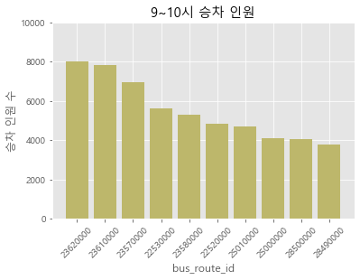

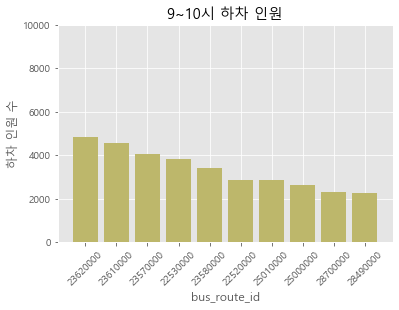

```python
data2 = train.groupby(['bus_route_id']).sum()[['9~10_ride']].reset_index()
data2=data2.sort_values(by='9~10_ride',ascending=False).head(10)
data2['bus_route_id'] = data3['bus_route_id'].astype(str)
plt.bar(x='bus_route_id',height='9~10_ride',data=data2, color='darkkhaki')
plt.xticks(rotation=45)
plt.ylim([0, 10000])
plt.title('9~10시 승차 인원')
plt.xlabel('bus_route_id')
plt.ylabel('승차 인원 수')
plt.show()

data2 = train.groupby(['bus_route_id']).sum()[['9~10_takeoff']].reset_index()
data2=data2.sort_values(by='9~10_takeoff',ascending=False).head(10)
data2['bus_route_id'] = data2['bus_route_id'].astype(str)
plt.bar(x='bus_route_id',height='9~10_takeoff',data=data2, color='darkkhaki')
plt.xticks(rotation=45)
plt.ylim([0, 10000])
plt.title('9~10시 하차 인원')
plt.xlabel('bus_route_id')
plt.ylabel('하차 인원 수')
plt.show()
```

**10~11시간대**의 이용객 수는 **23620000**번 노선이 가장 많습니다.

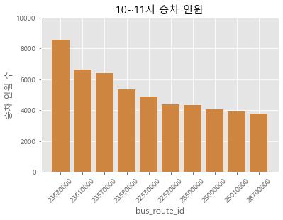

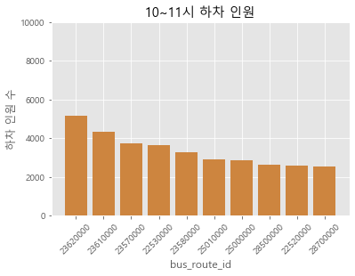

```python
data2 = train.groupby(['bus_route_id']).sum()[['10~11_ride']].reset_index()
data2=data2.sort_values(by='10~11_ride',ascending=False).head(10)
data2['bus_route_id'] = data2['bus_route_id'].astype(str)
plt.bar(x='bus_route_id',height='10~11_ride',data=data2, color='peru')
plt.xticks(rotation=45)
plt.ylim([0, 10000])
plt.title('10~11시 승차 인원')
plt.xlabel('bus_route_id')
plt.ylabel('승차 인원 수')
plt.show()

data2 = train.groupby(['bus_route_id']).sum()[['10~11_takeoff']].reset_index()
data2=data2.sort_values(by='10~11_takeoff',ascending=False).head(10)
data2['bus_route_id'] = data2['bus_route_id'].astype(str)
plt.bar(x='bus_route_id',height='10~11_takeoff',data=data2, color='peru')
plt.xticks(rotation=45)
plt.ylim([0, 10000])
plt.title('10~11시 하차 인원')
plt.xlabel('bus_route_id')
plt.ylabel('하차 인원 수')
plt.show()
```

**11~12시간대**의 이용객 수는 **23610000**번 노선이 가장 많습니다.

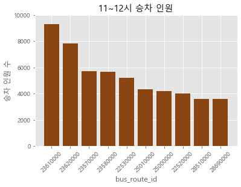

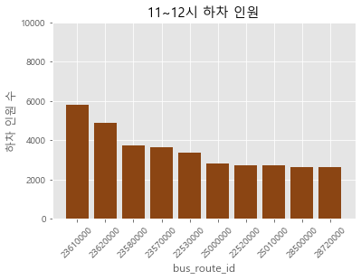

```python
data2 = train.groupby(['bus_route_id']).sum()[['11~12_ride']].reset_index()
data2=data2.sort_values(by='11~12_ride',ascending=False).head(10)
data2['bus_route_id'] = data2['bus_route_id'].astype(str)
plt.bar(x='bus_route_id',height='11~12_ride',data=data2, color='saddlebrown')
plt.xticks(rotation=45)
plt.ylim([0, 10000])
plt.title('11~12시 승차 인원')
plt.xlabel('bus_route_id')
plt.ylabel('승차 인원 수')
plt.show()

data2 = train.groupby(['bus_route_id']).sum()[['11~12_takeoff']].reset_index()
data2=data2.sort_values(by='11~12_takeoff',ascending=False).head(10)
data2['bus_route_id'] = data2['bus_route_id'].astype(str)
plt.bar(x='bus_route_id',height='11~12_takeoff',data=data2, color='saddlebrown')
plt.xticks(rotation=45)
plt.ylim([0, 10000])
plt.title('11~12시 하차 인원')
plt.xlabel('bus_route_id')
plt.ylabel('하차 인원 수')
plt.show()
```

**18~20시간대**의 이용객 수는 **23610000**번 노선이 가장 많습니다.

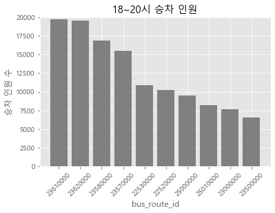

```python
data2 = train.groupby(['bus_route_id']).sum()[['18~20_ride']].reset_index()
data2=data2.sort_values(by='18~20_ride',ascending=False).head(10)
data2['bus_route_id'] = data2['bus_route_id'].astype(str)
plt.bar(x='bus_route_id',height='18~20_ride', data=data2, color='gray')
plt.xticks(rotation=45)
plt.ylim([0, 20000])
plt.title('18~20시 승차 인원')
plt.xlabel('bus_route_id')
plt.ylabel('승차 인원 수')
plt.show()
```

전체적인 결과, **23610000**번 노선의 이용률이 가장 높습니다.  
또한 버스 노선 이용객 수는 시간대와 상관없이 비슷한 것을 확인할 수 있습니다.

가장 이용률이 높은 **23610000번 버스에서 정차하는 정류장의 탑승 인원**을 조사했습니다.  
한달(2019년 9월) 정류장 이용순위는 다음과 같습니다.

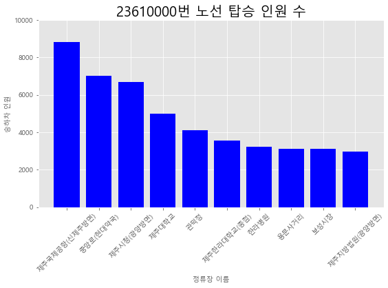

```python
data=train.loc[:,['id','date','bus_route_id','in_out','station_code','station_name','latitude','longitude',
                    'ride_sum','takeoff_sum', 'all_sum']]

data2=data.groupby(['bus_route_id','station_name'])['all_sum'].sum().to_frame().reset_index()

data3=data2[data2['bus_route_id']==23610000]
data3
data3=data3.sort_values(by='all_sum',ascending=False)
data3['bus_route_id'] = data3['bus_route_id'].astype(str)

fig = plt.figure(figsize=(9,5))
plt.bar(data=data3.head(10),x='station_name',height='all_sum',color='blue')
plt.xticks(rotation=45)
plt.ylim([0, 10000])
plt.xlabel('정류장 이름',size=10)
plt.ylabel('승하차 인원',size=10)
plt.title('23610000번 노선 탑승 인원 수',size=20)
plt.show()
```

23610000번 노선에 해당하는 정류장은 아래 지도에서 확인할 수 있습니다.

```python
addr2 = data[data['bus_route_id']==23610000][['station_name','latitude','longitude']]
addr2 = addr2.drop_duplicates()
addr_lat = addr2.sort_values(by=['latitude'],axis=0)
addr_long = addr2.sort_values(by=['longitude'],axis=0)

# 초기 지도 객체를 생성합니다.
map_osm = folium.Map(location=[33.3919083,126.5304598], zoom_start = 11)
for item in addr_lat.index:
    lat = addr_lat.loc[item, 'latitude']
    long = addr_long.loc[item, 'longitude']
    folium.Marker([lat, long], #위도 경도
        popup = addr_lat.loc[item,'station_name'],
        icon=folium.Icon(icon='cloud')
    ).add_to(map_osm)
map_osm
```

[interactive chart not shown]

### 2.3. weekday-time.csv 데이터를 사용하여 승하차가 많은 요일을 조사합니다.

요일별 결과, 승하차의 경우 월요일과 화요일이 가장 많은 것을 확인할 있습니다.

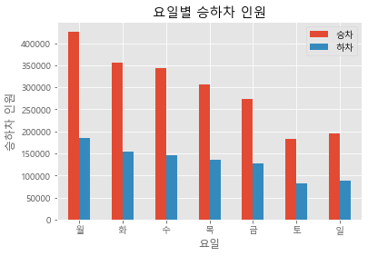

```python
weekday=pd.read_csv('weekday-time.csv', encoding='utf8')

weekday['weekday'] = weekday['weekday'].map({0:'월',1:'화',2:'수',3:'목',4:'금',5:'토',6:'일'})
weekday.rename(columns={'ride_sum': '승차', 'takeoff_sum': '하차'}, inplace=True)

weekday=weekday.loc[:,['weekday','승차','하차']]
weekday=weekday.set_index('weekday', drop='False')

weekday.plot(kind='bar')
plt.xticks(rotation=0.1)
plt.title('요일별 승하차 인원')
plt.xlabel('요일')
plt.ylabel('승하차 인원')
plt.show()
```

### 2.4. train.csv 데이터에서 분석한 상위 10개 정류장의 승객 유형을 bus_bts.csv로 살펴봅니다.

먼저 2019년 9월 한달 간 버스를 이용한 승객 유형을 조사해봅니다.

```
  user_category  user_count
0            일반     1488739
1           어린이       38069
2           청소년      282415
3            경로      473325
4          장애일반       73042
5          장애동반       67913
6          유공일반       15243
7          유공동반          91
```

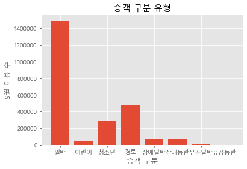

```python
user=bus_bts.groupby('user_category').sum().reset_index()
user['user_category'] = user['user_category'].map({1:'일반',2:'어린이',4:'청소년',6:'경로',27:'장애일반',28:'장애동반',29:'유공일반',30:'유공동반'})
print(user.loc[:,['user_category','user_count']])
plt.bar(data=user,x='user_category',height='user_count')
plt.title('승객 구분 유형')
plt.xlabel('승객 구분')
plt.ylabel('9월 이용 수')
plt.show()
#print(user.info())
```

앞서 train.csv로 분석한 결과, 승하차수가 높은 정류장은 `한라병원, 제주버스터미널, 제주시청(광양방면), 제주대학교, 제주시청(아라방면), <br>제주도청신제주로터리, 동문로터리(동문시장), 노형오거리, 제주시외버스터미널, 제주국제공항(구제주방면)`입니다.  
bus_bts.csv를 사용하여 **상위 10개 정류장을 이용하는 승객 유형**을 분석하고자 합니다.

```python
top10_bus = ['한라병원', '제주버스터미널', '제주시청(광양방면)', '제주대학교', '제주시청(아라방면)', '제주도청신제주로터리', '동문로터리(동문시장)', '노형오거리', '제주시외버스터미널', '제주국제공항(구제주방면)']

x = bus_bts.groupby(['geton_station_name','user_category']).size().to_frame('count').reset_index()
y = x[x['geton_station_name'].isin(top10_bus)]
y['user_category'] = y['user_category'].map({1:'일반',2:'어린이',4:'청소년',6:'경로',27:'장애일반',28:'장애동반',29:'유공일반',30:'유공동반'})
```

**<승객 유형 분석 결과>**  
**경로 승객** : `동문로터리(동문시장) 한라병원 제주시청(광양방면) 제주시외버스터미널`에 많습니다. (각 6천여명 이상)  
**장애(장애일반, 장애동반 합계) 승객** : `한라병원 제주시외버스터미널 제주시청(광양방면)`에 많습니다. (각 2천명 이상)  
**청소년 승객** : `한라병원 제주시청(아라방면) 제주시외버스터미널`에 많습니다. (각 3천명 이상)

참고할 점은 `제주국제공항(구제주방면)` 정류장에는 **일반 승객**이 대부분의 비율을 차지한다는 것입니다.

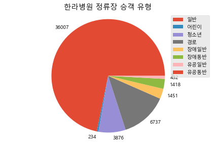

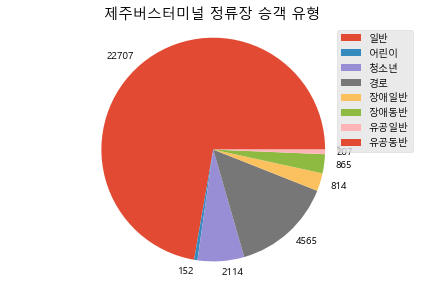

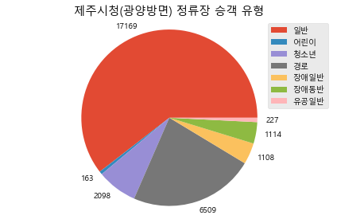

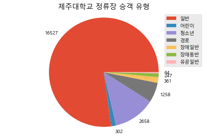

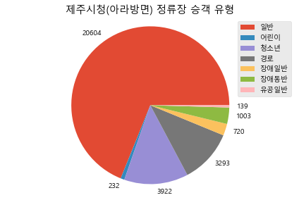

```python
no = y[y['geton_station_name']=='한라병원']
plt.title('한라병원 정류장 승객 유형')
patches = plt.pie(no['count'], labels=no['count'])
plt.legend(patches, labels=no['user_category'], loc='best')
plt.tight_layout()
plt.axis('equal')
plt.show()

no = y[y['geton_station_name']=='제주버스터미널']
plt.title('제주버스터미널 정류장 승객 유형')
patches = plt.pie(no['count'], labels=no['count'])
plt.legend(patches, labels=no['user_category'], loc='best')
plt.tight_layout()
plt.axis('equal')
plt.show()

no = y[y['geton_station_name']=='제주시청(광양방면)']
plt.title('제주시청(광양방면) 정류장 승객 유형')
patches = plt.pie(no['count'], labels=no['count'])
plt.legend(patches, labels=no['user_category'], loc='best')
plt.tight_layout()
plt.axis('equal')
plt.show()

no = y[y['geton_station_name']=='제주대학교']
plt.title('제주대학교 정류장 승객 유형')
patches = plt.pie(no['count'], labels=no['count'])
plt.legend(patches, labels=no['user_category'], loc='best')
plt.tight_layout()
plt.axis('equal')
plt.show()

no = y[y['geton_station_name']=='제주시청(아라방면)']
plt.title('제주시청(아라방면) 정류장 승객 유형')
patches = plt.pie(no['count'], labels=no['count'])
plt.legend(patches, labels=no['user_category'], loc='best')
plt.tight_layout()
plt.axis('equal')
plt.show()
```

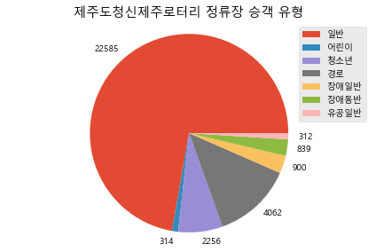

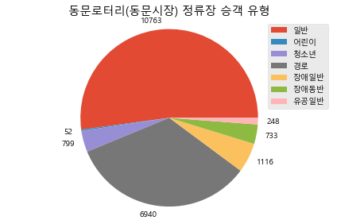

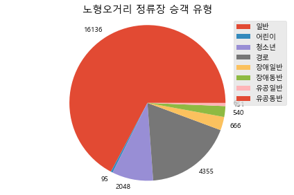

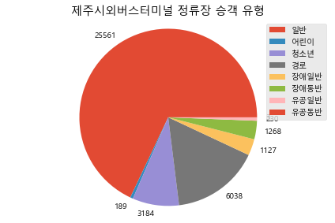

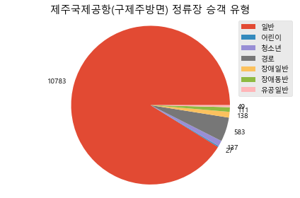

```python
no = y[y['geton_station_name']=='제주도청신제주로터리']
plt.title('제주도청신제주로터리 정류장 승객 유형')
patches = plt.pie(no['count'], labels=no['count'])
plt.legend(patches, labels=no['user_category'], loc='best')
plt.tight_layout()
plt.axis('equal')
plt.show()

no = y[y['geton_station_name']=='동문로터리(동문시장)']
plt.title('동문로터리(동문시장) 정류장 승객 유형')
patches = plt.pie(no['count'], labels=no['count'])
plt.legend(patches, labels=no['user_category'], loc='best')
plt.tight_layout()
plt.axis('equal')
plt.show()

no = y[y['geton_station_name']=='노형오거리']
plt.title('노형오거리 정류장 승객 유형')
patches = plt.pie(no['count'], labels=no['count'])
plt.legend(patches, labels=no['user_category'], loc='best')
plt.tight_layout()
plt.axis('equal')
plt.show()

no = y[y['geton_station_name']=='제주시외버스터미널']
plt.title('제주시외버스터미널 정류장 승객 유형')
patches = plt.pie(no['count'], labels=no['count'])
plt.legend(patches, labels=no['user_category'], loc='best')
plt.tight_layout()
plt.axis('equal')
plt.show()

no = y[y['geton_station_name']=='제주국제공항(구제주방면)']
plt.title('제주국제공항(구제주방면) 정류장 승객 유형')
patches = plt.pie(no['count'], labels=no['count'])
plt.legend(patches, labels=no['user_category'], loc='best')
plt.tight_layout()
plt.axis('equal')
plt.show()
```

## 3. 결론: 교통체증 해결방안 제시

### 3.1. 분석결과

- 버스 노선마다 승하차 인원이 크게 차이납니다.
- 승하차율은 인구밀집과 높은 상관성을 보입니다.
- 승하차수가 가장 높은 정류장은 한라병원입니다. 이용률이 가장 높은 버스 노선은 23610000입니다.
- 월요일과 화요일에 버스 이용률이 높습니다.
- 동문로터리(동문시장), 한라병원, 제주시청(광양방면), 제주시외버스터미널 정류장에 경로 승객이 각 6천여명 이상 됩니다.
- 한라병원, 제주시외버스터미널, 제주시청(광양방면) 정류장에 장애 승객이 각 2천명 이상 됩니다.
- 한라병원, 제주시청(아라방면), 제주시외버스터미널 정류장에 청소년 승객이 각 3천명 이상 됩니다.

### 3.2. 아이디어 제시

- 경로, 장애 승객 유형이 많은 정류장은 해당 유형에 필요한 편의시설을 확보하여 빠른 승하차를 도울 필요가 있습니다.
- 가장 많이 이용하는 혼잡 시간대 버스를 이용하는 승객에게 인센티브 마일리지를 부여하여 대중교통 이용률을 높이는 것을 제안합니다.
- 인구가 밀집된 지역에서는 버스 승하차 인원이 많기 때문에 교통혼잡이 예상됩니다.  
  제주도민의 만족감과 상관없이 승하차 인원이 적은 구역이 많아 노선 개선이 필요해 보입니다.